[KLEBER PEREZ](https://www.linkedin.com/in/kleberperez/)

DATA 606 - PROJECT PROPOSAL  
SOURCE FILES AND RMARKDOWN ON [RPUBS](http://rpubs.com/kleberperez/482016) AND [GITHUB](https://github.com/kleberperez1/CUNY-SPS-Data606-Project-Proposal)

### Load Libraries

```r
# load libraries

library(kableExtra)
#suppressMessages(suppressWarnings(library(tidyverse)))
library(tidyr)
library(dplyr)
library(psych)
library(stringr)
```

### Data Wrangling

Data source from fivethirtyeight github repo

```r
# Load data and Subset data by category
url1 <- "https://raw.githubusercontent.com/kleberperez1/CUNY-SPS-Data606-Project-Proposal/master/all_ages.csv"
all_ages <- url1 %>%
  read.csv(stringsAsFactors = FALSE) %>%
  tbl_df() %>%
  arrange(Major_category)

kable(head(all_ages, 20)) %>%
  kable_styling("striped", "hovered", font_size = 12) %>%
  scroll_box(height = "500px")
```

| Major_code | Major | Major_category | Total | Employed | Employed_full_time_year_round | Unemployed | Unemployment_rate | Median | P25th | P75th |
| --- | --- | --- | --- | --- | --- | --- | --- | --- | --- | --- |
| 1100 | GENERAL AGRICULTURE | Agriculture & Natural Resources | 128148 | 90245 | 74078 | 2423 | 0.0261471 | 50000 | 34000 | 80000 |
| 1101 | AGRICULTURE PRODUCTION AND MANAGEMENT | Agriculture & Natural Resources | 95326 | 76865 | 64240 | 2266 | 0.0286361 | 54000 | 36000 | 80000 |
| 1102 | AGRICULTURAL ECONOMICS | Agriculture & Natural Resources | 33955 | 26321 | 22810 | 821 | 0.0302483 | 63000 | 40000 | 98000 |
| 1103 | ANIMAL SCIENCES | Agriculture & Natural Resources | 103549 | 81177 | 64937 | 3619 | 0.0426789 | 46000 | 30000 | 72000 |
| 1104 | FOOD SCIENCE | Agriculture & Natural Resources | 24280 | 17281 | 12722 | 894 | 0.0491884 | 62000 | 38500 | 90000 |
| 1105 | PLANT SCIENCE AND AGRONOMY | Agriculture & Natural Resources | 79409 | 63043 | 51077 | 2070 | 0.0317909 | 50000 | 35000 | 75000 |
| 1106 | SOIL SCIENCE | Agriculture & Natural Resources | 6586 | 4926 | 4042 | 264 | 0.0508671 | 63000 | 39400 | 88000 |
| 1199 | MISCELLANEOUS AGRICULTURE | Agriculture & Natural Resources | 8549 | 6392 | 5074 | 261 | 0.0392304 | 52000 | 35000 | 75000 |
| 1302 | FORESTRY | Agriculture & Natural Resources | 69447 | 48228 | 39613 | 2144 | 0.0425633 | 58000 | 40500 | 80000 |
| 1303 | NATURAL RESOURCES MANAGEMENT | Agriculture & Natural Resources | 83188 | 65937 | 50595 | 3789 | 0.0543413 | 52000 | 37100 | 75000 |
| 6000 | FINE ARTS | Arts | 571961 | 386961 | 256747 | 29912 | 0.0717533 | 45000 | 30000 | 70000 |
| 6001 | DRAMA AND THEATER ARTS | Arts | 174817 | 135071 | 81519 | 11789 | 0.0802737 | 42000 | 29000 | 62000 |
| 6002 | MUSIC | Arts | 276262 | 192704 | 116142 | 11155 | 0.0547192 | 45000 | 30000 | 67000 |
| 6003 | VISUAL AND PERFORMING ARTS | Arts | 55141 | 41098 | 23479 | 4297 | 0.0946580 | 40000 | 27000 | 59000 |
| 6004 | COMMERCIAL ART AND GRAPHIC DESIGN | Arts | 504657 | 379980 | 266671 | 30330 | 0.0739197 | 46600 | 32000 | 70000 |
| 6005 | FILM VIDEO AND PHOTOGRAPHIC ARTS | Arts | 133508 | 107651 | 69303 | 10080 | 0.0856189 | 47000 | 30000 | 70000 |
| 6007 | STUDIO ARTS | Arts | 81008 | 58799 | 36943 | 5372 | 0.0837138 | 37600 | 24900 | 58000 |
| 6099 | MISCELLANEOUS FINE ARTS | Arts | 8511 | 6431 | 3802 | 1190 | 0.1561475 | 45000 | 30000 | 60000 |
| 1301 | ENVIRONMENTAL SCIENCE | Biology & Life Science | 106106 | 87602 | 65238 | 4736 | 0.0512898 | 52000 | 38000 | 75000 |
| 3600 | BIOLOGY | Biology & Life Science | 839454 | 583079 | 422788 | 36757 | 0.0593012 | 51000 | 35000 | 80000 |

### Subset by Category

```r
# Subsetting by Major Category
all_ages_ag <- all_ages %>%
  filter(Major_category == "Agriculture & Natural Resources")

kable(head(all_ages_ag, 20)) %>%
  kable_styling("striped", "hovered", font_size = 12) %>%
  scroll_box(height = "500px")
```

| Major_code | Major | Major_category | Total | Employed | Employed_full_time_year_round | Unemployed | Unemployment_rate | Median | P25th | P75th |
| --- | --- | --- | --- | --- | --- | --- | --- | --- | --- | --- |
| 1100 | GENERAL AGRICULTURE | Agriculture & Natural Resources | 128148 | 90245 | 74078 | 2423 | 0.0261471 | 50000 | 34000 | 80000 |
| 1101 | AGRICULTURE PRODUCTION AND MANAGEMENT | Agriculture & Natural Resources | 95326 | 76865 | 64240 | 2266 | 0.0286361 | 54000 | 36000 | 80000 |
| 1102 | AGRICULTURAL ECONOMICS | Agriculture & Natural Resources | 33955 | 26321 | 22810 | 821 | 0.0302483 | 63000 | 40000 | 98000 |
| 1103 | ANIMAL SCIENCES | Agriculture & Natural Resources | 103549 | 81177 | 64937 | 3619 | 0.0426789 | 46000 | 30000 | 72000 |
| 1104 | FOOD SCIENCE | Agriculture & Natural Resources | 24280 | 17281 | 12722 | 894 | 0.0491884 | 62000 | 38500 | 90000 |
| 1105 | PLANT SCIENCE AND AGRONOMY | Agriculture & Natural Resources | 79409 | 63043 | 51077 | 2070 | 0.0317909 | 50000 | 35000 | 75000 |
| 1106 | SOIL SCIENCE | Agriculture & Natural Resources | 6586 | 4926 | 4042 | 264 | 0.0508671 | 63000 | 39400 | 88000 |
| 1199 | MISCELLANEOUS AGRICULTURE | Agriculture & Natural Resources | 8549 | 6392 | 5074 | 261 | 0.0392304 | 52000 | 35000 | 75000 |
| 1302 | FORESTRY | Agriculture & Natural Resources | 69447 | 48228 | 39613 | 2144 | 0.0425633 | 58000 | 40500 | 80000 |
| 1303 | NATURAL RESOURCES MANAGEMENT | Agriculture & Natural Resources | 83188 | 65937 | 50595 | 3789 | 0.0543413 | 52000 | 37100 | 75000 |

### Apply Filter

```r
# Apply Filter on category
value_list <- c("Arts", "Biology & Life Science", "Business") #, "Communications & Journalism", "Computers & Mathematics",
                #"Education", "Engineering", "Health", "Humanities & Liberal Arts", "Industrial Arts & Consumer Services",
                #"Law & Public Policy", "Physical Sciences", "Psychology & Social Work", "Social Science")
all_ages_value <- all_ages %>%
  filter(Major_category %in% value_list)

kable(all_ages_value) %>%
  kable_styling("striped", "hovered", font_size = 12) %>%
  scroll_box(height = "500px")
```

| Major_code | Major | Major_category | Total | Employed | Employed_full_time_year_round | Unemployed | Unemployment_rate | Median | P25th | P75th |
| --- | --- | --- | --- | --- | --- | --- | --- | --- | --- | --- |
| 6000 | FINE ARTS | Arts | 571961 | 386961 | 256747 | 29912 | 0.0717533 | 45000 | 30000 | 70000 |
| 6001 | DRAMA AND THEATER ARTS | Arts | 174817 | 135071 | 81519 | 11789 | 0.0802737 | 42000 | 29000 | 62000 |
| 6002 | MUSIC | Arts | 276262 | 192704 | 116142 | 11155 | 0.0547192 | 45000 | 30000 | 67000 |
| 6003 | VISUAL AND PERFORMING ARTS | Arts | 55141 | 41098 | 23479 | 4297 | 0.0946580 | 40000 | 27000 | 59000 |
| 6004 | COMMERCIAL ART AND GRAPHIC DESIGN | Arts | 504657 | 379980 | 266671 | 30330 | 0.0739197 | 46600 | 32000 | 70000 |
| 6005 | FILM VIDEO AND PHOTOGRAPHIC ARTS | Arts | 133508 | 107651 | 69303 | 10080 | 0.0856189 | 47000 | 30000 | 70000 |
| 6007 | STUDIO ARTS | Arts | 81008 | 58799 | 36943 | 5372 | 0.0837138 | 37600 | 24900 | 58000 |
| 6099 | MISCELLANEOUS FINE ARTS | Arts | 8511 | 6431 | 3802 | 1190 | 0.1561475 | 45000 | 30000 | 60000 |
| 1301 | ENVIRONMENTAL SCIENCE | Biology & Life Science | 106106 | 87602 | 65238 | 4736 | 0.0512898 | 52000 | 38000 | 75000 |
| 3600 | BIOLOGY | Biology & Life Science | 839454 | 583079 | 422788 | 36757 | 0.0593012 | 51000 | 35000 | 80000 |
| 3601 | BIOCHEMICAL SCIENCES | Biology & Life Science | 75322 | 52594 | 37103 | 4056 | 0.0715975 | 53000 | 33000 | 82000 |
| 3602 | BOTANY | Biology & Life Science | 14135 | 9284 | 6333 | 327 | 0.0340235 | 50000 | 32000 | 75000 |
| 3603 | MOLECULAR BIOLOGY | Biology & Life Science | 28197 | 20221 | 13366 | 1303 | 0.0605371 | 45000 | 30000 | 70000 |
| 3604 | ECOLOGY | Biology & Life Science | 45368 | 36708 | 25677 | 1888 | 0.0489170 | 47500 | 32000 | 73000 |
| 3605 | GENETICS | Biology & Life Science | 6362 | 4747 | 3498 | 206 | 0.0415910 | 48000 | 33000 | 80000 |
| 3606 | MICROBIOLOGY | Biology & Life Science | 68885 | 45422 | 33990 | 2435 | 0.0508807 | 60000 | 40000 | 85000 |
| 3607 | PHARMACOLOGY | Biology & Life Science | 5015 | 3481 | 2579 | 57 | 0.0161108 | 60000 | 35000 | 105000 |
| 3608 | PHYSIOLOGY | Biology & Life Science | 43984 | 31394 | 20207 | 1692 | 0.0511395 | 50000 | 30000 | 75000 |
| 3609 | ZOOLOGY | Biology & Life Science | 55395 | 35714 | 26152 | 1815 | 0.0483626 | 55000 | 34000 | 85000 |
| 3611 | NEUROSCIENCE | Biology & Life Science | 13676 | 8987 | 5446 | 665 | 0.0688976 | 35000 | 28000 | 52000 |
| 3699 | MISCELLANEOUS BIOLOGY | Biology & Life Science | 29389 | 22298 | 16508 | 1114 | 0.0475824 | 52000 | 33500 | 72800 |
| 4006 | COGNITIVE SCIENCE AND BIOPSYCHOLOGY | Biology & Life Science | 6898 | 5527 | 3639 | 284 | 0.0488728 | 53000 | 31500 | 93000 |
| 6200 | GENERAL BUSINESS | Business | 2148712 | 1580978 | 1304646 | 85626 | 0.0513775 | 60000 | 40000 | 95000 |
| 6201 | ACCOUNTING | Business | 1779219 | 1335825 | 1095027 | 75379 | 0.0534147 | 65000 | 42500 | 100000 |
| 6202 | ACTUARIAL SCIENCE | Business | 9763 | 7846 | 6880 | 466 | 0.0560635 | 72000 | 53000 | 115000 |
| 6203 | BUSINESS MANAGEMENT AND ADMINISTRATION | Business | 3123510 | 2354398 | 1939384 | 147261 | 0.0588653 | 58000 | 39500 | 86000 |
| 6204 | OPERATIONS LOGISTICS AND E-COMMERCE | Business | 57200 | 47341 | 41104 | 2141 | 0.0432683 | 65000 | 45000 | 90000 |
| 6205 | BUSINESS ECONOMICS | Business | 75547 | 57983 | 48471 | 3816 | 0.0617486 | 65000 | 45000 | 100000 |
| 6206 | MARKETING AND MARKETING RESEARCH | Business | 1114624 | 890125 | 704912 | 51839 | 0.0550329 | 56000 | 38500 | 90000 |
| 6207 | FINANCE | Business | 816548 | 670681 | 561073 | 34166 | 0.0484729 | 65000 | 45000 | 100000 |
| 6209 | HUMAN RESOURCES AND PERSONNEL MANAGEMENT | Business | 187274 | 142879 | 116466 | 9241 | 0.0607481 | 54000 | 38000 | 80000 |
| 6210 | INTERNATIONAL BUSINESS | Business | 86064 | 66453 | 51012 | 5106 | 0.0713537 | 54000 | 38600 | 80000 |
| 6211 | HOSPITALITY MANAGEMENT | Business | 200854 | 163393 | 122499 | 8862 | 0.0514470 | 49000 | 33000 | 70000 |
| 6212 | MANAGEMENT INFORMATION SYSTEMS AND STATISTICS | Business | 156673 | 134478 | 118249 | 6186 | 0.0439771 | 72000 | 50000 | 100000 |
| 6299 | MISCELLANEOUS BUSINESS & MEDICAL ADMINISTRATION | Business | 102753 | 77471 | 61603 | 4308 | 0.0526786 | 53000 | 36000 | 83000 |

### Graduate Students

```r
# Load graduate students file and subset data

url2 <- "https://raw.githubusercontent.com/kleberperez1/CUNY-SPS-Data606-Project-Proposal/master/grad_students.csv"
grad_stdnt <- url2 %>% read.csv(stringsAsFactors = FALSE) %>% tbl_df() %>% arrange(Major_category)

grad_ag <- grad_stdnt %>%
  filter(Major_category == "Agriculture & Natural Resources")

kable(head(grad_ag, 20)) %>%
  kable_styling("striped", "hovered", font_size = 12) %>%
  scroll_box(height = "500px")
```

| Major_code | Major | Major_category | Grad_total | Grad_sample_size | Grad_employed | Grad_full_time_year_round | Grad_unemployed | Grad_unemployment_rate | Grad_median | Grad_P25 | Grad_P75 | Nongrad_total | Nongrad_employed | Nongrad_full_time_year_round | Nongrad_unemployed | Nongrad_unemployment_rate | Nongrad_median | Nongrad_P25 | Nongrad_P75 | Grad_share | Grad_premium |
| --- | --- | --- | --- | --- | --- | --- | --- | --- | --- | --- | --- | --- | --- | --- | --- | --- | --- | --- | --- | --- | --- |
| 1101 | AGRICULTURE PRODUCTION AND MANAGEMENT | Agriculture & Natural Resources | 17488 | 386 | 13104 | 11207 | 473 | 0.0348383 | 67000 | 41600 | 100000 | 89169 | 71781 | 61335 | 1869 | 0.0253768 | 55000 | 38000 | 80000 | 0.1639649 | 0.2181818 |
| 1100 | GENERAL AGRICULTURE | Agriculture & Natural Resources | 44306 | 764 | 28930 | 23024 | 874 | 0.0293249 | 68000 | 45000 | 104000 | 123984 | 86631 | 72409 | 2352 | 0.0264320 | 50000 | 34000 | 80000 | 0.2632717 | 0.3600000 |
| 1302 | FORESTRY | Agriculture & Natural Resources | 24713 | 487 | 16831 | 14102 | 725 | 0.0412964 | 78000 | 52000 | 110000 | 67649 | 46815 | 39048 | 1885 | 0.0387064 | 59000 | 42000 | 80000 | 0.2675667 | 0.3220339 |
| 1303 | NATURAL RESOURCES MANAGEMENT | Agriculture & Natural Resources | 29357 | 659 | 23394 | 19087 | 711 | 0.0294960 | 70000 | 50000 | 100000 | 77101 | 60690 | 48256 | 3413 | 0.0532424 | 53000 | 38000 | 75000 | 0.2757613 | 0.3207547 |
| 1105 | PLANT SCIENCE AND AGRONOMY | Agriculture & Natural Resources | 30983 | 624 | 22782 | 18312 | 735 | 0.0312540 | 67000 | 45000 | 100000 | 76190 | 60241 | 49506 | 1899 | 0.0305600 | 50000 | 35000 | 75000 | 0.2890933 | 0.3400000 |
| 1102 | AGRICULTURAL ECONOMICS | Agriculture & Natural Resources | 14800 | 305 | 10592 | 8768 | 216 | 0.0199852 | 80000 | 53000 | 120000 | 33049 | 25557 | 22496 | 734 | 0.0279183 | 63000 | 40000 | 99000 | 0.3093064 | 0.2698413 |
| 1106 | SOIL SCIENCE | Agriculture & Natural Resources | 3335 | 61 | 2284 | 1641 | 34 | 0.0146678 | 65000 | 50000 | 91000 | 6242 | 4654 | 3917 | 264 | 0.0536804 | 65000 | 41000 | 89000 | 0.3482301 | 0.0000000 |
| 1103 | ANIMAL SCIENCES | Agriculture & Natural Resources | 56807 | 1335 | 47755 | 39047 | 596 | 0.0123265 | 70300 | 48000 | 104000 | 94910 | 74896 | 61629 | 3101 | 0.0397579 | 48000 | 32000 | 75000 | 0.3744274 | 0.4645833 |
| 1199 | MISCELLANEOUS AGRICULTURE | Agriculture & Natural Resources | 5032 | 98 | 2758 | 2276 | 261 | 0.0864525 | 54000 | 45000 | 81000 | 8092 | 5978 | 4707 | 239 | 0.0384430 | 55000 | 39000 | 78000 | 0.3834197 | -0.0181818 |
| 1104 | FOOD SCIENCE | Agriculture & Natural Resources | 14521 | 266 | 10857 | 8074 | 370 | 0.0329563 | 72000 | 50000 | 110000 | 22853 | 16298 | 12431 | 681 | 0.0401084 | 63000 | 40000 | 92000 | 0.3885321 | 0.1428571 |

### Recent Graduates

```r
# Load graduate students file and subset data
url3 <- "https://raw.githubusercontent.com/kleberperez1/CUNY-SPS-Data606-Project-Proposal/master/recent_grads.csv"
rct_grad <- url3 %>% read.csv(stringsAsFactors = FALSE) %>% tbl_df() %>% arrange(Major_category)

rct_ag <- rct_grad %>%
  filter(Major_category == "Agriculture & Natural Resources")

kable(head(rct_ag, 20)) %>%
  kable_styling("striped", "hovered", font_size = 12) %>%
  scroll_box(height = "500px")
```

| Rank | Major_code | Major | Total | Men | Women | Major_category | ShareWomen | Sample_size | Employed | Full_time | Part_time | Full_time_year_round | Unemployed | Unemployment_rate | Median | P25th | P75th | College_jobs | Non_college_jobs | Low_wage_jobs |
| --- | --- | --- | --- | --- | --- | --- | --- | --- | --- | --- | --- | --- | --- | --- | --- | --- | --- | --- | --- | --- |
| 22 | 1104 | FOOD SCIENCE | NA | NA | NA | Agriculture & Natural Resources | NA | 36 | 3149 | 2558 | 1121 | 1735 | 338 | 0.0969315 | 53000 | 32000 | 70000 | 1183 | 1274 | 485 |
| 64 | 1101 | AGRICULTURE PRODUCTION AND MANAGEMENT | 14240 | 9658 | 4582 | Agriculture & Natural Resources | 0.3217697 | 273 | 12323 | 11119 | 2196 | 9093 | 649 | 0.0500308 | 40000 | 25000 | 50000 | 1925 | 6221 | 1362 |
| 65 | 1100 | GENERAL AGRICULTURE | 10399 | 6053 | 4346 | Agriculture & Natural Resources | 0.4179248 | 158 | 8884 | 7589 | 2031 | 5888 | 178 | 0.0196425 | 40000 | 30000 | 50000 | 2418 | 4717 | 839 |
| 72 | 1102 | AGRICULTURAL ECONOMICS | 2439 | 1749 | 690 | Agriculture & Natural Resources | 0.2829028 | 44 | 2174 | 1819 | 620 | 1528 | 182 | 0.0772496 | 40000 | 27000 | 54000 | 535 | 893 | 94 |
| 108 | 1303 | NATURAL RESOURCES MANAGEMENT | 13773 | 8617 | 5156 | Agriculture & Natural Resources | 0.3743556 | 152 | 11797 | 10722 | 2613 | 6954 | 842 | 0.0666192 | 35000 | 25000 | 42000 | 4333 | 5808 | 1405 |
| 112 | 1302 | FORESTRY | 3607 | 3156 | 451 | Agriculture & Natural Resources | 0.1250347 | 48 | 3007 | 2473 | 891 | 1763 | 322 | 0.0967257 | 35000 | 28600 | 48000 | 1096 | 1692 | 327 |
| 113 | 1106 | SOIL SCIENCE | 685 | 476 | 209 | Agriculture & Natural Resources | 0.3051095 | 4 | 613 | 488 | 185 | 383 | 0 | 0.0000000 | 35000 | 18500 | 44000 | 355 | 144 | 0 |
| 144 | 1105 | PLANT SCIENCE AND AGRONOMY | 7416 | 4897 | 2519 | Agriculture & Natural Resources | 0.3396710 | 110 | 6594 | 5798 | 1246 | 4522 | 314 | 0.0454545 | 32000 | 22900 | 40000 | 2089 | 3545 | 1231 |
| 153 | 1103 | ANIMAL SCIENCES | 21573 | 5347 | 16226 | Agriculture & Natural Resources | 0.7521439 | 255 | 17112 | 14479 | 5353 | 10824 | 917 | 0.0508625 | 30000 | 22000 | 40000 | 5443 | 9571 | 2125 |
| 162 | 1199 | MISCELLANEOUS AGRICULTURE | 1488 | 404 | 1084 | Agriculture & Natural Resources | 0.7284946 | 24 | 1290 | 1098 | 335 | 936 | 82 | 0.0597668 | 29000 | 23000 | 42100 | 483 | 626 | 31 |

### Research question

Which college majors offer the best opportunities in terms of unemployment rate and salary?

### Cases

All_ages - Each case represents majors offered by colleges and universities in the US. There are 173 majors represented. These data include both undergrads and grad students.

Grad Students - Each case represents majors offered by colleges and universities in the US. There are 173 majors represented. These data include only grad students aged 25+ years.

Recent Grads - Each case represents majors offered by colleges and universities in the US. There are 173 majors represented. These data include only undergraduate students aged < 28 years. These data also include gender statistics.

### Data collection

These Data were collated by the [fivethirtyeight](http://www.fivethirtyeight.com) website and was posted to their github page [college major](https://github.com/fivethirtyeight/data/tree/master/college-major).

### Type of study

This is an observational Study

### Explanatory Variables

The explanatory variables are the counts of employed and unemployed college degree holders and the statistics of their income. These data are numerical.

### Relevant summary statistics

First we will look at overall unemployment rate for the 3 categories: all ages, recent grads, and grad students.

```r
summary(all_ages$Unemployment_rate)
```

```
##    Min. 1st Qu.  Median    Mean 3rd Qu.    Max.
## 0.00000 0.04626 0.05472 0.05736 0.06904 0.15615
```

```r
summary(rct_grad$Unemployment_rate)
```

```
##    Min. 1st Qu.  Median    Mean 3rd Qu.    Max.
## 0.00000 0.05031 0.06796 0.06819 0.08756 0.17723
```

```r
summary(grad_stdnt$Grad_unemployment_rate)
```

```
##    Min. 1st Qu.  Median    Mean 3rd Qu.    Max.
## 0.00000 0.02607 0.03665 0.03934 0.04805 0.13851
```

```r
DT::datatable(summary(all_ages), options = list(pageLength = 7))
```

|  | Var1 | Var2 | Freq |
| --- | --- | --- | --- |
|  |  | Major_code | Min. :1100 |
|  |  | Major_code | 1st Qu.:2403 |
|  |  | Major_code | Median :3608 |
|  |  | Major_code | Mean :3880 |
|  |  | Major_code | 3rd Qu.:5503 |
|  |  | Major_code | Max. :6403 |
|  |  | Major | Length:173 |
|  |  | Major | Class :character |
|  |  | Major | Mode :character |
|  |  | Major |  |

[output cut: 56 more lines]

```r
DT::datatable(summary(all_ages_ag), list(pageLength = 7))
```

|  | Var1 | Var2 | Freq |
| --- | --- | --- | --- |
|  |  | Major_code | Min. :1100 |
|  |  | Major_code | 1st Qu.:1102 |
|  |  | Major_code | Median :1104 |
|  |  | Major_code | Mean :1152 |
|  |  | Major_code | 3rd Qu.:1176 |
|  |  | Major_code | Max. :1303 |
|  |  | Major | Length:10 |
|  |  | Major | Class :character |
|  |  | Major | Mode :character |
|  |  | Major |  |

[output cut: 56 more lines]

```r
DT::datatable(summary(rct_grad), list(pageLength = 7))
```

|  | Var1 | Var2 | Freq |
| --- | --- | --- | --- |
|  |  | Rank | Min. : 1 |
|  |  | Rank | 1st Qu.: 44 |
|  |  | Rank | Median : 87 |
|  |  | Rank | Mean : 87 |
|  |  | Rank | 3rd Qu.:130 |
|  |  | Rank | Max. :173 |
|  |  | Rank |  |
|  |  | Major_code | Min. :1100 |
|  |  | Major_code | 1st Qu.:2403 |
|  |  | Major_code | Median :3608 |

[output cut: 137 more lines]

### Unemployment Rate

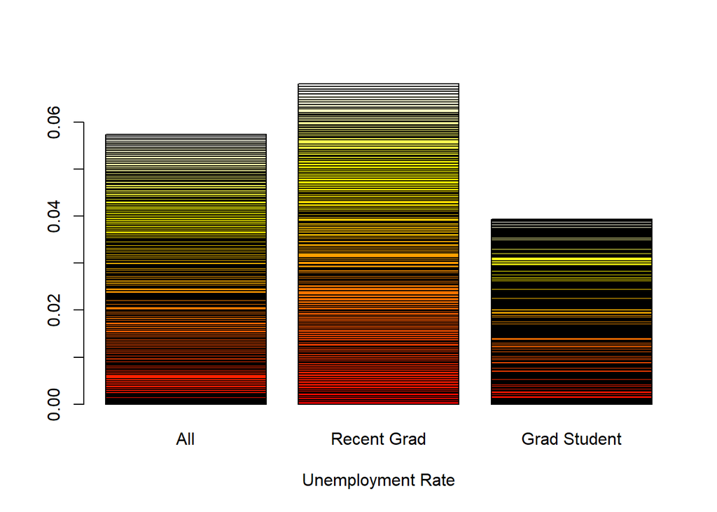

```r
unempl <- cbind(all_ages$Unemployment_rate, rct_grad$Unemployment_rate, grad_stdnt$Grad_unemployment_rate)
barplot(unempl/nrow(unempl), names.arg = c("All", "Recent Grad", "Grad Student"),
        xlab = "Unemployment Rate", col = heat.colors(nrow(unempl)))
```

It appears that people holding only a Bachelor’s degree have nearly twice as high median unemployment as those with higher degrees.  
We will also look at median income for the three categories.

### Median Income by Major All Ages (USD)

```r
summary(all_ages$Median)
```

```
##    Min. 1st Qu.  Median    Mean 3rd Qu.    Max.
##   35000   46000   53000   56816   65000  125000
```

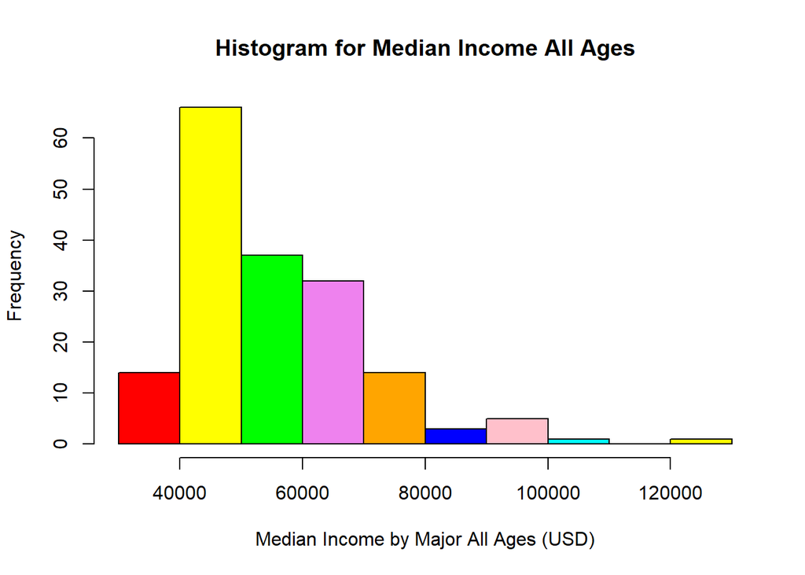

```r
colors = c("red", "yellow", "green", "violet", "orange", "blue", "pink", "cyan")
hist(all_ages$Median, main = "Histogram for Median Income All Ages",
     xlab = "Median Income by Major All Ages (USD)", col = colors)
```

### Median Income by Major Recent Graduates (USD)

```r
options(scipen = 999)
summary(rct_grad$Median)
```

```
##    Min. 1st Qu.  Median    Mean 3rd Qu.    Max.
##   22000   33000   36000   40151   45000  110000
```

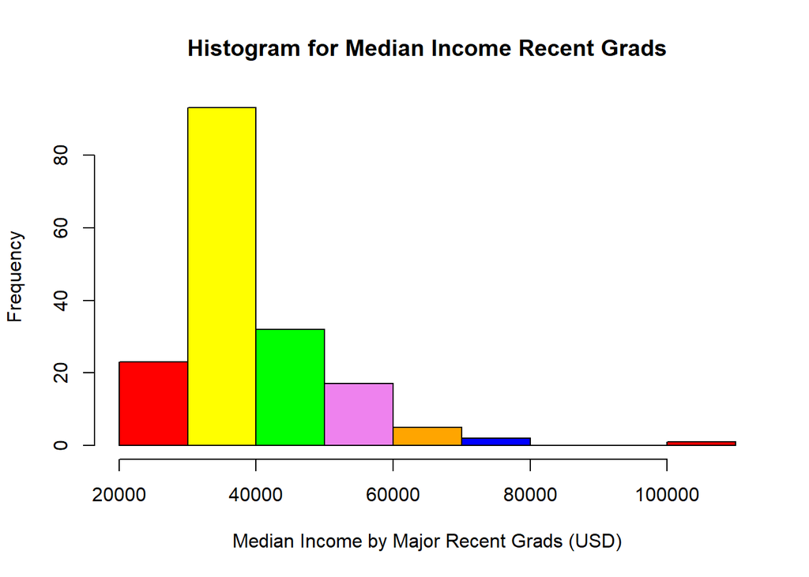

```r
hist(rct_grad$Median, main = "Histogram for Median Income Recent Grads",
     xlab = "Median Income by Major Recent Grads (USD)", col = colors)
```

### Median Income by Graduate Students (USD)

```r
summary(grad_stdnt$Grad_median)
```

```
##    Min. 1st Qu.  Median    Mean 3rd Qu.    Max.
##   47000   65000   75000   76756   90000  135000
```

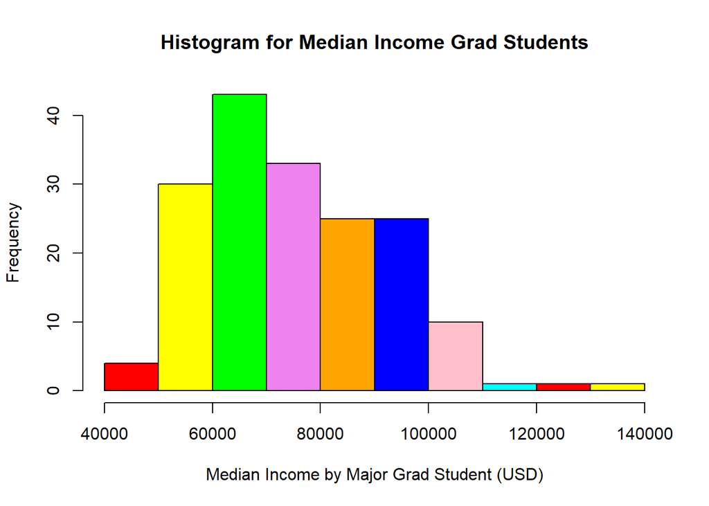

```r
hist(grad_stdnt$Grad_median, main = "Histogram for Median Income Grad Students",
     xlab = "Median Income by Major Grad Student (USD)", col = colors)
```

### All, Recent Graduate and Graduate Students Median Salary

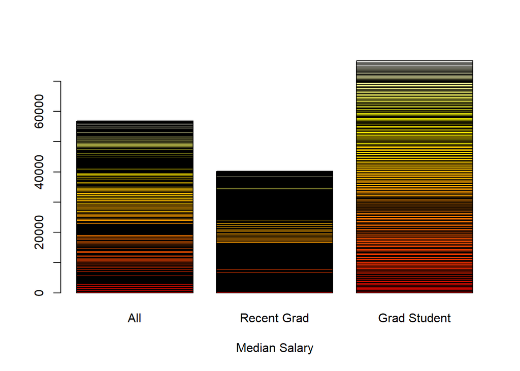

```r
medsal <- cbind(all_ages$Median, rct_grad$Median, grad_stdnt$Grad_median)
barplot(medsal/nrow(medsal), names.arg = c("All", "Recent Grad", "Grad Student"),
        xlab = "Median Salary", col = heat.colors(nrow(unempl)))
```

> *Please email to:* Kleber Perez *for any suggestion.*